# Big Data & Business Intelligence

4. Lazy Learning – Classification Using K Nearest Neighbors

Wen-Bin Chuang

## Introduction

“Birds of a feather flock together”. Data science uses this principle to classify data by placing it in the same category as **similar** or “**k nearest**” neighbors.

**K nearest neighbors** is a simple algorithm that stores all available cases and classifies new cases based on a similarity measure (e.g., distance functions).

You will learn:

- The key concepts that define nearest neighbor classifiers, and why they are considered “lazy” learners
- Methods to measure the similarity of two examples using distance
- To apply a popular nearest neighbor classifier called k-NN

# Algorithm

Nearest neighbor classifiers are well-suited for **classification** tasks. The nearest neighbors approach to classification is exemplified by the **k-nearest neighbors algorithm** (k-NN).

The letter $k$ is a variable term implying that any number of nearest neighbors could be used. In particular, the “nearest” in similarity. The k-NN algorithm treats the features as coordinates in a multidimensional feature space

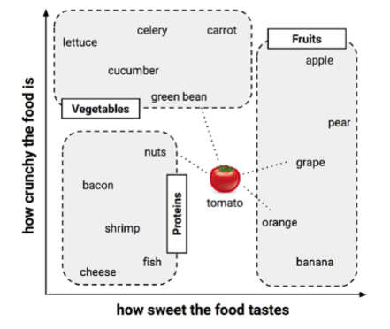

## Measuring Similarity with Distance

Traditionally, the k-NN algorithm uses **Euclidean distance**, which is the distance one would measure if it were possible to use a ruler to connect two points.

A case is then classified by a **majority vote** of its neighbors, with the case being assigned to the class most common amongst its K nearest neighbors measured by a **distance function**.

Distance Function

Euclidean $\left(\sum_{i=1}^{k}(x_{i}-y_{i})^{2}\right)^{1/2}$

Manhattan $\sum_{i=1}^{k}|x_{i}-y_{i}|$

Minkowski $\left(\sum_{i=1}^{k}\left(|x_{i}-y_{i}|\right)^{q}\right)^{1/q}$

## Appropriate k

The balance between over fitting and under fitting the training data is a problem known as **bias-variance tradeoff**.

Choosing a large k reduces the impact or variance caused by noisy data, but can bias the learner

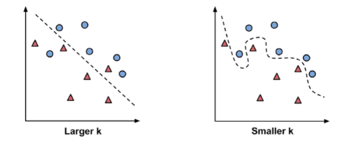

- One common practice is to begin with k equal to the **square root of the number of training examples**. Choosing the optimal value for K is best done by first inspecting the data.
- In general, a large K value is more precise as it reduces the overall noise but there is no guarantee.
- Cross-validation is another way to retrospectively determine a good K value by using an independent dataset to validate the K value.
- Historically, the optimal K for most datasets has been between 3-10.

## Preparing data for use with k-NN

Before algorithm for nearest neighbor classification, Features are typically transformed to a standard range prior to applying the k-NN algorithm.

The traditional method of rescaling features for k-NN is **min-max normalization**.

This process transforms a feature such that all of its values fall in a range between 0 and 1.
$$x=\frac{x-x_{min}}{x_{max}-x_{min}}$$

Another common transformation is called z-score standardization.
$$x=\frac{x-mean(x)}{std\left(x\right)}$$

- The Euclidean distance formula is not defined for **nominal data**. It should also be noted that all three distance measures are only valid for **continuous variables**.
- In the instance of **categorical variables** the **Hamming distance** must be used. It also brings up the issue of standardization of the numerical variables between 0 and 1 when there is a mixture of numerical and categorical variables in the dataset.

Hamming Distance
$$D_{H}=\sum_{i=1}^{k}|x_{i}-y_{i}|$$

$$\begin{array}{c}
x=y\Rightarrow D=0\\
x\neq y\Rightarrow D=1
\end{array}$$

| X | y | Distance |
| --- | --- | --- |
| Male | Male | 0 |
| Male | Female | 1 |

Typical solution utilizes dummy coding, where a value of 1 indicates one category, and 0, the other.

$$male=\begin{cases}
\begin{array}{l}
1,\\
0,
\end{array} & \begin{array}{l}
\textrm{if x = male}\\
otherwise
\end{array}\end{cases}$$

An n-category nominal feature can be dummy coded by creating the binary indicator variables for (n - 1) levels of the feature. The dummy coding for a three-category temperature variable (for example, hot, medium, or cold) could be set up as (3 - 1) = 2 features
$$hot=\begin{cases}
\begin{array}{l}
1,\\
0,
\end{array} & \begin{array}{l}
\textrm{if x = hot}\\
otherwise
\end{array}\end{cases}$$
$$𝑚𝑒𝑑𝑖𝑢𝑚=\begin{cases}
\begin{array}{l}
1,\\
0,
\end{array} & \begin{array}{l}
\textrm{if x = 𝑚𝑒𝑑𝑖𝑢𝑚}\\
otherwise
\end{array}\end{cases}$$

A convenient aspect of dummy coding is that the distance between dummy coded features is always one or zero, and thus, the values fall on the same scale as min-max normalized numeric data.